# Insuring Chaos: Reinsurance for a Jackie Chan Movie

⚠️ Draft — under review

Bavo D.C. Campo

2026-05-27

# 1 The Setup: Why Insuring Chaos Matters

Imagine, you are an insurer with a contract to cover a movie starring Jackie Chan. You are not entirely sure why you decided to do this and are getting a bit nervous, especially since Jackie Chan insists on doing his own stunts. The kind involving jumping off clock towers, sliding down glass skyscrapers, and fighting twenty people with a ladder. However, with everyone in the company being a huge Jackie Chan fan, the whole team is determined to make this work.

Our actuary, Sarah A. Ggregate has been a long-time fan and is one step ahead of everyone. She has already calibrated the underlying loss distribution using stunt data from a large collection of movies, because if you are insuring someone willing to jump from buildings, the least you can do is model it properly.

Sarah knows that this is not a normal risk. From experience, and from watching the films, she knows the loss process has a familiar but uncomfortable pattern:

- most days nothing happens,
- some days come with minor injuries or delays,
- every once in a while something spectacularly expensive occurs (e.g., Jackie Chan destroys the whole film set and puts the production on hold).

Sarah decides to model the loss during the filming period using the collective risk framework:

$$S = \sum_{i=1}^{N} X_i$$

where $N$ denotes the number of incidents occurring during the movie filming, $X_i$ the individual loss amount generated by incident $i$ and $S$ the aggregate loss. We assume that the $X_i$ are independent and identically distributed. Additionally, we assume that the number of incidents $N$ is independent of the individual loss amounts $X_i$.

On paper, this looks reassuringly simple. Count the incidents, sum their costs, and move on. In practice, however, this is where the trouble starts and Sarah knows. Most incidents are harmless, but a few are not, and those few dominate everything that follows. Filming lasts only a few months, but this is more than enough. One badly timed stunt can outweigh weeks of uneventful shooting. This is a heavy‑tailed risk. **The model is not challenged by typical days, but by the worst one.**

# 2 Modeling Heavy Tails: The Loss Distribution

With these assumptions, we have two components that jointly describe the loss process. One component that describes *how often* incidents occur during filming (claim frequency), and another one that describes the size of each individual loss amount when they do (claim severity).

We opt to model the claim frequency as

$$N \sim \text{Poisson}(\lambda).$$

Next, we consider modeling the distribution of the individual loss amount. It is important to acknowledge that not all incidents are of the same nature. Most days on set, stunts are planned, controlled, and insured accordingly, leading to moderate and fairly predictable losses. Occasionally, however, an incident falls outside this routine, typically when Jackie Chan has yet another crazy idea and executes it on the spot without practicing, and the resulting loss can be orders of magnitude larger. A single severity distribution is not flexible enough to capture both behaviours.

Since Jackie Chan occasionally goes all out, a single severity distribution will not work. Instead, we split the distribution of individual loss amounts into two parts: the **main body** (lognormal) and an **extreme tail** (Pareto). We model this using a piecewise severity distribution:

- Body (threshold $u$ and below): lognormal. This captures routine stunt costs.
- Tail (above $u$): Pareto. This captures catastrophic “Jackie goes all-out” losses.

The threshold $u$ marks the boundary between **“normal accident”** and **“oh no…”**

Let $S_X^{\mathrm{LN}}(x)=1-F_X^{\mathrm{LN}}(x)$ denote the survival function of a log-normal distribution with parameters $(\mu,\sigma^2)$, and let $u>0$ be a high threshold separating the attritional from the large losses. We define the survival function as

$$S_X(x)=
\begin{cases}
S_X^{\mathrm{LN}}(x), & x\le u,\\[6pt]
S_X^{\mathrm{LN}}(u)\left(\dfrac{u}{x}\right)^{\alpha}, & x>u,
\end{cases}
\qquad \alpha>0.$$

Scaling the Pareto tail by $S_X^{\mathrm{LN}}(u)$ preserves the probability mass and ensures that the probabilities beyond $u$ are correctly normalized, preventing discontinuities or misallocation of tail risk. The cumulative distribution function is given by

$$F_X(x)=
\begin{cases}
1-S_X^{\mathrm{LN}}(x)=F_X^{\mathrm{LN}}(x), & x\le u,\\[6pt]
1-S_X^{\mathrm{LN}}(u)\left(\dfrac{u}{x}\right)^{\alpha}, & x>u.
\end{cases}$$

This body–tail construction implies the following behaviour for losses below and above the threshold $u$:

- For losses below the threshold $u$, the individual loss amount follows a log-normal distribution, reflecting routine and well‑controlled incidents.
- Beyond $u$, the density decays according to a Pareto law, indicating that extreme losses become disproportionately more likely than under light‑tailed models.
- This separation ensures that high quantiles and tail‑based risk measures are driven by rare events rather than by typical losses.

The difference between a pure lognormal body and our piecewise model becomes clear when we visualize both (see Figure 1). The lognormal alone underestimates how often truly catastrophic losses occur. This is shown in the plot on the right side (losses beyond €50M). The piecewise distribution stays elevated compared to the pure lognormal. This is the Pareto tail at work.

Figure 1: Distribution of individual loss amounts: lognormal body with Pareto tail

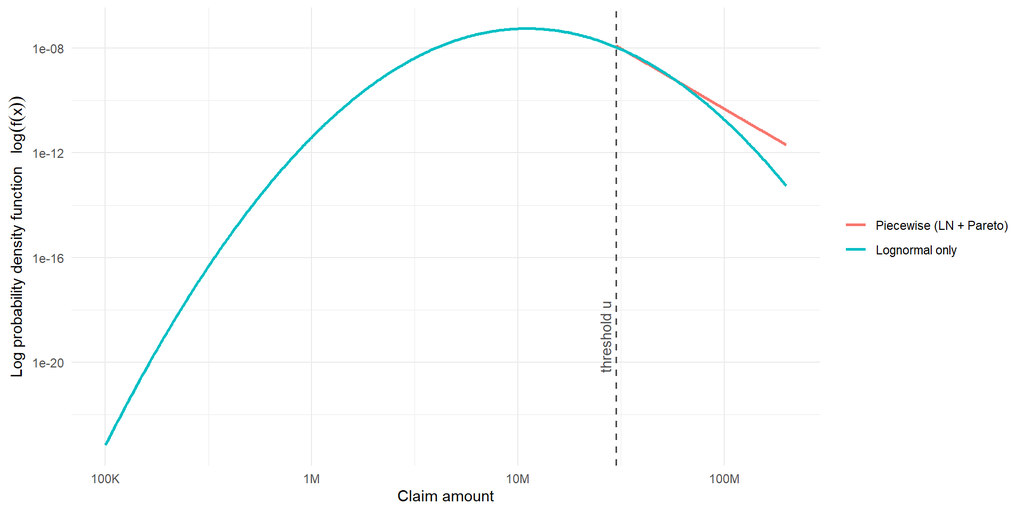

```r
# --- Parameters ---
mu_ln0  = log(15e6)  # lognormal location calibrated to historical routine losses
sig_ln0 = 0.55       # lognormal scale calibrated to moderate dispersion
u0      = 30e6       # threshold for major incidents
alpha0  = 3.6        # Pareto tail index calibrated for realistic extreme-loss decay

# --- Piecewise PDF definition ---
d_piecewise = function(x, u, meanlog, sdlog, alpha){
  ifelse(
    x <= u,
    dlnorm(x, meanlog = meanlog, sdlog = sdlog),
    (1 - plnorm(u, meanlog = meanlog, sdlog = sdlog)) *
      alpha * u^alpha / x^(alpha + 1)
  )
}

# Grid for plotting
x_grid = exp(seq(log(1e5), log(2e8), length.out = 500))

# PDFs
pdf_piecewise = d_piecewise(x_grid, u0, mu_ln0, sig_ln0, alpha0)
pdf_lognormal = dlnorm(x_grid, meanlog = mu_ln0, sdlog = sig_ln0)

df_pdf  = data.frame(
  x     = rep(x_grid, 2),
  pdf   = c(pdf_piecewise, pdf_lognormal),
  model = factor(
    rep(c("Piecewise (LN + Pareto)", "Lognormal only"), each = length(x_grid)),
    levels = c("Piecewise (LN + Pareto)", "Lognormal only")
  )
)

# --- ggplot ---
ggplot(df_pdf, aes(x = x, y = pdf, color = model)) +
  geom_line(linewidth = 0.9) +
  geom_vline(xintercept = u0, linetype = "dashed",
             linewidth = 0.6, color = "grey30") +
  annotate("text", x = u0, y = min(pdf_piecewise),
           label = "threshold u", angle = 90,
           vjust = -0.5, hjust = -1,
           color = "grey30", size = 3.5) +
  scale_x_log10(labels = label_number(scale_cut = cut_short_scale())) +
  scale_y_log10() +
  labs(
    x     = expression("Claim amount"),
    y     = expression("Log probability density function  " ~ log(f(x))),
    color = NULL
  ) +
  theme_minimal()
```

To examine the resulting loss dynamics, we perform a Monte Carlo simulation with 100,000 runs and the following parameter values:

- frequency $N \sim \text{Poisson}(\lambda=2.0)$;
- severity:
  - body $X_i \sim \text{Lognormal}(\mu=\log(15\text{M}),\sigma=0.55)$ up to threshold $u=30\text{M}$;
  - tail $X_i \mid X_i > u \sim \text{Pareto}(u,\alpha=3.6)$.

These values are chosen to be representative for a **large, stunt-heavy single movie risk**:

- $\lambda = 2.0$: implies roughly two insured incidents per production period on average, which is consistent with a high-complexity shoot where most days are normal but multiple reportable events are plausible .
- $\mu=\log(15\text{M})$: sets the body of the severity distribution around a large-loss scale relevant for major productions (material stunt incidents, delays, and set damage), not routine minor claims .
- $\sigma=0.55$: allows substantial dispersion around that body level so outcomes are heterogeneous across productions, while avoiding unrealistically diffuse routine-loss behavior.
- $u=30\text{M}$: places the body-tail boundary at a level that separates major incidents from truly exceptional events, consistent with a “major-loss” threshold on a high-budget production .
- $\alpha=3.6$: keeps a heavy tail (catastrophic outcomes remain possible) but with a decay fast enough to avoid implausible multi-billion simulated losses dominating a single-film example; this aligns with solvency-focused tail calibration practice where capital standards are expressed at extreme quantiles.

```r
# Parameters
mu_ln0  = log(15e6)  # lognormal location calibrated to historical routine losses
sig_ln0 = 0.55       # lognormal scale calibrated to moderate dispersion
u0      = 30e6       # threshold between "routine" and "extreme"
alpha0  = 3.6        # Pareto tail index calibrated to avoid implausible extremes

# Piecewise claim amount sampler via inverse-CDF:
# F(x)=F_LN(x) for x<=u, and F(x)=1-S_LN(u)*(u/x)^alpha for x>u
r_claim_amount = function(n, u = u0, alpha = alpha0, meanlog = mu_ln0, sdlog = sig_ln0){
  if (n <= 0) return(numeric(0))

  Fu  = plnorm(u, meanlog = meanlog, sdlog = sdlog)
  Su  = 1 - Fu
  p   = runif(n)
  out = numeric(n)

  in_body = p <= Fu
  out[in_body] = qlnorm(p[in_body], meanlog = meanlog, sdlog = sdlog)

  # Invert 1 - Su*(u/x)^alpha = p for p > Fu
  if (any(!in_body)) {
    v = (1 - p[!in_body]) / Su
    out[!in_body] = u * v^(-1 / alpha)
  }

  out
}

# Aggregate loss simulation - returns list with both aggregate and individual claims
simulate_year = function(lambda = 2.0){
  N           = rpois(1, lambda)
  if (N == 0) return(list(S = 0, claims = numeric(0)))
  claims = r_claim_amount(N)
  list(S = sum(claims), claims = claims)
}

# Run parallel simulations
n_sims = sampleSize
plan(multisession, workers = availableCores() - 1)  # Use all except 1 core
simulations = future_replicate(n_sims, simulate_year(), simplify = FALSE)
plan(sequential)  # Reset to sequential

# Extract aggregate losses
S = sapply(simulations, function(x) x$S)
```

For each simulated filming period, we

1. simulate the number of claims $N$,
2. generate $N$ individual loss amounts from the piecewise severity model,
3. sum them to obtain aggregate loss $S$. Figure 2 displays the resulting aggregate loss distribution obtained from the simulation.

Figure 2: Aggregate loss distribution: single Jackie Chan movie

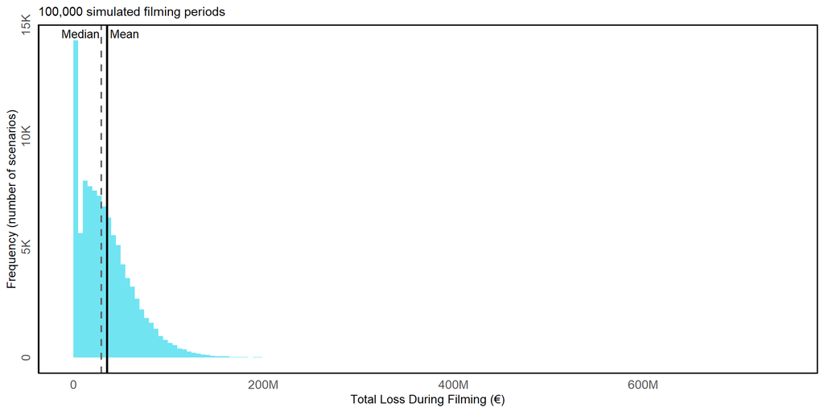

```r
df_agg = data.frame(Loss = S)

ggplot(df_agg, aes(x = Loss)) +
  geom_histogram(bins = 150, fill = plotColors$Base$Blue, alpha = 0.7, boundary = 0) +
  geom_vline(xintercept = mean(S), linetype = "solid", linewidth = 1, color = "black") +
  geom_vline(xintercept = median(S), linetype = "dashed", linewidth = 0.8, color = "grey40") +
  scale_x_continuous(labels = label_number(scale_cut = cut_short_scale())) +
  scale_y_continuous(labels = label_number(scale_cut = cut_short_scale())) +
  labs(
    x        = "Total Loss During Filming (€)",
    y        = "Frequency (number of scenarios)",
    subtitle = paste(format(sampleSize, big.mark = ",", scientific = FALSE), "simulated filming periods")
  ) +
  annotate("text", x = mean(S), y = Inf, label = "Mean", hjust = -0.1, vjust = 1.5, size = 3.5) +
  annotate("text", x = median(S), y = Inf, label = "Median", hjust = 1.05, vjust = 1.5, size = 3.5) +
  theme_minimal() +
  themePlot
```

The figure shows the distribution of total filming losses across 100,000 simulated scenarios. Most filming periods cluster around the €20-60M range, with a tail into the €140M+ region for severe scenarios. We observe a strong right skew in the distribution. As a result, the mean lies above the median, reflecting the influence of rare but severe losses that pull the average upward. **This asymmetry is exactly why reinsurance exists**, to handle those rare and expensive tail events.

# 3 If You Are Going to Insure Chaos, Transfer the Tail

Even though Sarah is a huge Jackie Chan fan, but she still has an uneasy feeling about the potential for large losses that can bankrupt her company. She knows that the risk of a catastrophic loss is real and that her company needs to be protected. Additionally, knowing that the loss distribution is heavy‑tailed, she recognizes that covering these rare but extreme losses entirely with own capital would be inefficient. Maintaining enough capital to survive a 1‑in‑200‑year event would require a substantial capital buffer, potentially locking up resources that could be used more efficiently elsewhere.

Before discussing reinsurance structures, we first quantify **why the tail is the core problem**. The key issue is not the average filming year, but the capital required to survive the worst outcomes. Once that capital pressure is clear, reinsurance becomes a financing and risk-transfer decision. You pay a predictable premium now to reduce solvency stress in extreme scenarios.

## 3.1 Why Tail Risk Matters: VaR and Solvency II Capital Requirements

Without reinsurance, one extreme year can wipe out profits and jeopardize solvency. To quantify this tail risk in a regulatory framework, Solvency II measures the required capital using the Value at Risk (VaR) at the 99.5% confidence level

$$P(S \leq \text{VaR}_{99.5\%}(S)) = 0.995.$$

This is the aggregate loss level below which 99.5% of outcomes fall. Equivalently, aggregate losses exceed this level in only $(1-0.995) = 0.5\%$ of scenarios and this threshold is therefore often referred to as the “1-in-200” event.

A related measure is the **Tail Value at Risk** (TVaR) or **Conditional Value at Risk**, which measures the *average* loss in the worst 0.5% of outcomes

$$\text{TVaR}_{99.5\%}(S) = \mathbb{E}[S \mid S \ge \text{VaR}_{99.5\%}(S)].$$

As such, the TVaR provides insight into how bad tail events are on average.

When working with an aggregate loss distribution, two related but distinct quantities matter:

1. **Total Buffer Required:** The full amount needed to survive a 1-in-200 year is $\text{VaR}_{99.5\%}(S)$.
2. **Solvency Capital Requirement (SCR):** Since you have already set aside **Technical Provisions** (reserves) to cover the expected aggregate loss $\mathbb{E}[S]$ in the ordinary course of business, the “extra” capital you must hold in addition to these reserves is

$$\text{SCR} = \text{VaR}_{99.5\%}(S) - \mathbb{E}[S].$$

This capital requirement measures the gap between the tail and the average. Technical Provisions are mandatory balance-sheet liabilities designed to cover the expected aggregate loss. The SCR is the solvency buffer *on top of* these provisions. Solvency II asks: “After accounting for normal expected losses, how much extra capital do you need to survive the worst 0.5% of scenarios?” The answer is $\text{SCR} = \text{VaR}_{99.5\%}(S) - \mathbb{E}[S]$.

> **Critical Insight.** We buy reinsurance to avoid an event that probably will not happen. The true value emerges when the tail event *does* occur. You do not go bankrupt. You are buying protection against tail scenarios and the ruin they would otherwise bring.

## 3.2 Why Reinsurance Exists

Given this tail-risk and capital picture, the motivation for reinsurance becomes straightforward:

1. **Capital constraint:** You do not have €100M in capital sitting idle for a tail event that occurs once every 200 years. But paying €2-3M per year to a reinsurer is digestible. Over time, economics favor transfer.
2. **Risk aggregation:** Reinsurers insure thousands of businesses worldwide. A catastrophic stunt movie loss is tiny to them. To you, it is existential.
3. **Earnings stability:** Volatile earnings (€70M loss one year, €50M profit the next) terrify investors and raise your cost of capital. Reinsurance caps your losses and smooths the P&L.
4. **Regulatory capital:** Under Solvency II, large tail exposures translate directly into higher required capital. Reinsurance can materially reduce that burden.
5. **Ratings and financing:** Rating agencies and lenders care about tail risk. Better protection can improve financing conditions and external confidence.
6. **Risk appetite and governance:** Even when a treaty does not maximize a single numerical criterion, management may still prefer it because it limits peak losses and makes outcomes more tolerable for the board.

## 3.3 Computing Capital Requirements from Tail Risk

Let’s calculate the capital requirement for our example without any reinsurance. Table 1 depicts the central-loss statistics, tail metrics, and the resulting capital requirement. On average, the movie costs €35.15M to insure, while the typical year is more forgiving (median around €29.49M). The gap between mean and median indicates that extreme years pull the average, and the tail metrics in the same table quantify how severe those rare outcomes can be.

```r
# Risk measure functions
VaR  = function(x, a) quantile(x, a)
TVaR = function(x, a) {
  q  = VaR(x, a)
  mean(x[x >= q])
}

alpha                = 0.995  # 1-in-200 event (Solvency II standard)
K_gross              = VaR(S, alpha) - mean(S)  # Solvency Capital Requirement per Solvency II
loss_capital_summary = data.frame(
  Metric             = c(
    "Mean aggregate loss",
    "Median aggregate loss",
    "Std deviation",
    "VaR(99.5%) [1-in-200]",
    "TVaR(99.5%)",
    "Capital Requirement (SCR)"
  ),
  Interpretation = c(
    "Average annual insured loss",
    "Typical annual insured loss",
    "Volatility around the mean",
    "1-in-200 loss threshold",
    "Average loss in the worst 0.5% scenarios",
    "VaR(99.5%) - Mean loss"
  ),
  Value = c(
    paste0("€", format(round(mean(S)/1e6, 2), big.mark=","), "M"),
    paste0("€", format(round(median(S)/1e6, 2), big.mark=","), "M"),
    paste0("€", format(round(sd(S)/1e6, 2), big.mark=","), "M"),
    paste0("€", format(round(VaR(S, alpha)/1e6, 2), big.mark=","), "M"),
    paste0("€", format(round(TVaR(S, alpha)/1e6, 2), big.mark=","), "M"),
    paste0("€", format(round(K_gross/1e6, 2), big.mark=","), "M")
  )
)

knitr::kable(
  loss_capital_summary,
  align = "lll", caption = "Gross-loss summary and Solvency II capital requirement", table.attr = "style='width:100%;'"
)
```

Table 1: Gross-loss summary and Solvency II capital requirement

| Metric | Interpretation | Value |
| --- | --- | --- |
| Mean aggregate loss | Average annual insured loss | €35.15M |
| Median aggregate loss | Typical annual insured loss | €29.49M |
| Std deviation | Volatility around the mean | €29.82M |
| VaR(99.5%) [1-in-200] | 1-in-200 loss threshold | €145.29M |
| TVaR(99.5%) | Average loss in the worst 0.5% scenarios | €177.12M |
| Capital Requirement (SCR) | VaR(99.5%) - Mean loss | €110.14M |

Table 1 tells the catastrophe story. At the 99.5% confidence level (1-in-200 scenarios), losses hit €145.29M, while TVaR(99.5%) quantifies average severity inside that worst tail. The same table also reports the resulting capital requirement (SCR = VaR(99.5%) - Mean), which is the extra buffer required to survive the 1-in-200 year.

This capital requirement is what matters operationally. Since the tail is long, this number is large. Worse, this capital sits idle 99.5% of the time (given that you correctly modeled the process), earning nothing. This is the economic problem reinsurance solves. Instead of holding this capital, you pay a premium to transfer the tail risk to someone else. Figure 3 visualizes the gross loss distribution with the key risk statistics marked.

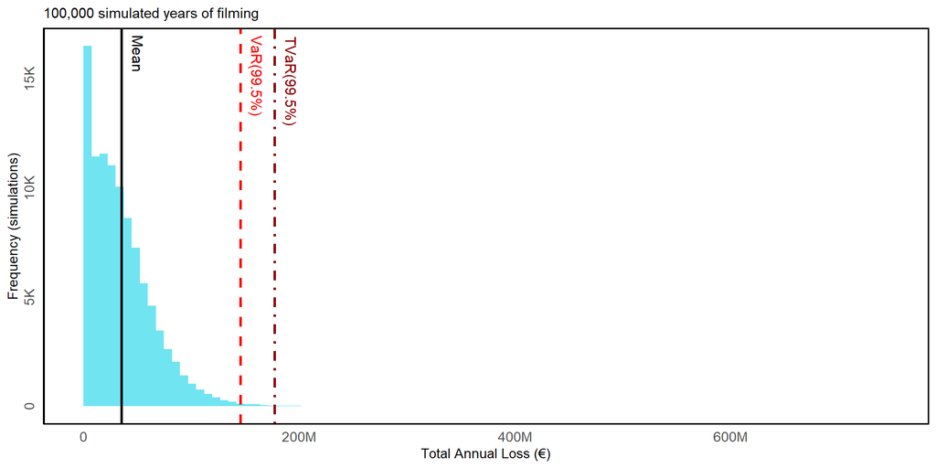

```r
df_loss <- data.frame(Loss = S)

sizeText = 4
ggplot(df_loss, aes(x = Loss)) +
  geom_histogram(bins = 100, fill = plotColors$Base$Blue, alpha = 0.7, boundary = 0) +
  geom_vline(xintercept = mean(S), linetype = "solid", linewidth = 1, color = "black") +
  geom_vline(xintercept = VaR(S, 0.995), linetype = "dashed", linewidth = 1, color = "red") +
  geom_vline(xintercept = TVaR(S, 0.995), linetype = "dotdash", linewidth = 1, color = "darkred") +
  scale_x_continuous(labels = label_number(scale_cut = cut_short_scale())) +
  scale_y_continuous(labels = label_number(scale_cut = cut_short_scale())) +
  labs(
    x = "Total Annual Loss (€)",
    y = "Frequency (simulations)",
    subtitle = paste(format(sampleSize, big.mark = ",", scientific = FALSE), "simulated years of filming")
  ) +
  annotate("text", x = mean(S), y = Inf, label = "Mean", hjust = -0.2, vjust = -1, size = sizeText, angle = 270) +
  annotate("text", x = VaR(S, 0.995), y = Inf, label = "VaR(99.5%)", hjust = -0.1, vjust = -1, color = "red", size = sizeText, angle = 270) +
  annotate("text", x = TVaR(S, 0.995), y = Inf, label = "TVaR(99.5%)", hjust = -0.1, vjust = -1, color = "darkred", size = sizeText, angle = 270) +
  theme_minimal() +
  themePlot
```

# 4 How to Share the Chaos: Reinsurance Structures

The first step in thinking about reinsurance is to determine whether the exposure is a single risk or a portfolio of risks.

In the case of a single Jackie Chan film, the exposure is clearly defined and can be presented to a reinsurer on a stand‑alone basis. The resulting bespoke agreement, negotiated risk by risk, is referred to as **facultative reinsurance**.

On the other hand, if you are a production company making five films a year with dozens of risks across your portfolio, you might say, “I am going to insure several movies. Give me a standing agreement that automatically covers all of them without renegotiating each time.” This is **treaty reinsurance**. A blanket agreement that applies automatically to all risks in your portfolio that meet the agreed criteria.

The trade-off is straightforward. Facultative gives you complete flexibility and precision for each risk, but you negotiate every single time. Treaty gives you automatic protection for your entire book of business, so you are not renegotiating deals constantly.

For this single Jackie Chan movie, facultative reinsurance is the obvious choice. You are protecting one specific, high-risk production with custom terms negotiated just for this film. There is no portfolio of films to amortize costs across, no standing agreement to justify.

## 4.1 Reinsurance Structures: Understanding Recovery Functions

The next question is **Which reinsurance structures can we choose from?** In other words, when Jackie Chan’s stunt goes wrong and we file a claim, how much does the reinsurer actually pay us?

We can describe reinsurance using a **recovery function** $R(L)$. Given loss $L$, the reinsurer pays $R(L)$. The shape of this function determines how much capital we freed up, how expensive the premium is, and whether the whole deal makes sense economically.

Before looking at specific treaty structures, it is essential to grasp the distinction between proportional and non‑proportional reinsurance.**Proportional** reinsurance operates like a partnership. The reinsurer receives a fixed share of the premium and pays the same fixed share of every loss, regardless of size. **Non‑proportional** reinsurance, by contrast, is targeted protection. The reinsurer assumes liability only for losses within a predefined layer (for example, losses above €10M and up to €50M), and the premium reflects the risk of that specific slice of the loss distribution.

> Across the various reinsurance structures, we use $A$ to denote the **loss threshold** below which the insurer retains 100% of losses, called the retention, attachment point, or deductible depending on perspective. It marks the boundary where the reinsurer begins to participate.

# 5 Proportional Structures

## 5.1 Quota Share: “Co-Produce the Movie”

This is one of the simplest reinsurance arrangements. In a quota share the insurer and the reinsurer share all claims and premiums proportionally. That is, you **cede** (transfer) a fixed percentage of each claim (and premium) to the reinsurer. This **cession rate** $\alpha$ is constant across all risks and decided at underwriting. The recovery function is given by

$$R_{\text{QS}}(X_i) = \alpha \cdot X_i$$

where

- $\alpha$ = **cession rate** (the % of each claim you transfer to the reinsurer);
- $(1 - \alpha)$ = **retention ratio** (the % of each claim you keep).

For example, a 30% Quota Share means $\alpha = 0.30$:

- You **cede 30%** of every claim to the reinsurer
- You **retain 70%** of every claim yourself
- On a €3M claim: you keep €2.1M (70%) and cede €0.9M (30%) to reinsurer
- On a €60M claim: you keep €42M (70%) and cede €18M (30%) to reinsurer

A quota share is best understood as a co-production arrangement. Everything that happens (profit or loss) is split 70%-30%. Good years, bad years, all the same split.

**Pros:** Simple, predictable, easy to calculate.  
**Cons:** You **bleed capital even in good years** (cede 30% of profits). Expensive if all you want is tail protection.

Figure 4 visualizes the Quota Share recovery function. Because this structure is purely proportional, recovery grows linearly with claim size at a constant slope equal to the cession rate. This makes the mechanism transparent, but it also shows that you cede part of every claim, not only the extreme ones.

Figure 4: Quota Share recovery: proportional split of all claims

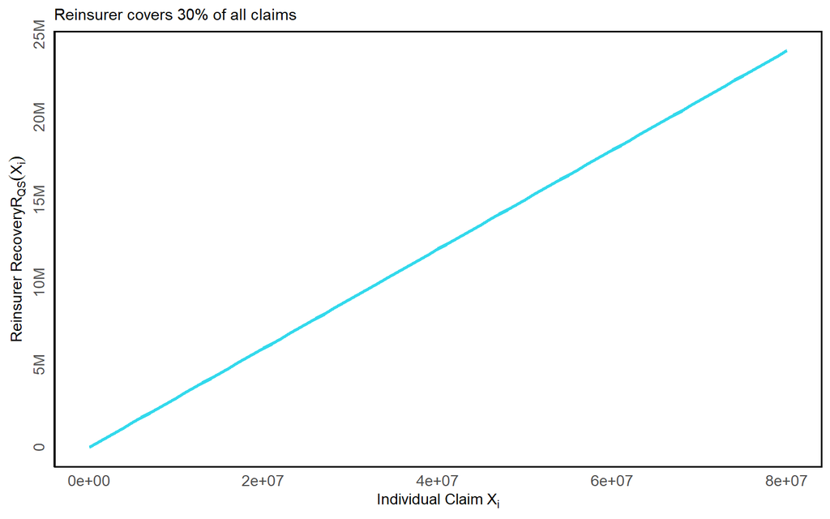

```r
X_demo = seq(0, 80e6, by = 1e6)
alpha_qs = 0.3
R_qs     = alpha_qs * X_demo
df_qs    = data.frame(Claim = X_demo, Recovery = R_qs)
ggplot(df_qs, aes(x = Claim, y = Recovery)) +
  geom_line(linewidth = 1.2, color = plotColors$Base$Blue) +
  scale_y_continuous(labels = label_number(scale_cut = cut_short_scale())) +
  labs(
    x        = expression("Individual Claim" ~ X[i]),
    y        = expression("Reinsurer Recovery" ~ R["QS"](X[i])),
    subtitle = "Reinsurer covers 30% of all claims"
  ) +
  theme_minimal() + themePlot
```

## 5.2 Surplus Lines: “Protecting Large Exposures”

Surplus is a proportional, capacity‑based structure designed to handle large, individual risks that exceed an insurer’s per‑risk appetite. In practice, surplus reinsurance is written as a treaty covering a portfolio, but applied risk by risk, with each exposure assessed against the agreed retention $A$ and treaty capacity $nA$. Unlike Quota Share, which applies uniformly across all risks, Surplus applies only when the sum insured $SI$ exceeds the insurer’s retention $A$, after which premiums and losses are shared proportionally.

The cession rate **for risk** $i$, for which $SI_i > A$, is calculated as
$$\alpha_i = \min\left(\frac{nA}{SI_i},\; \max\left(0, 1-\frac{A}{SI_i}\right)\right)$$

where

- $SI_i$ = sum insured on risk $i$ (the contractual upper bound of liability)
- $A$ = retention (amount insurer keeps per risk)
- $n$ = number of lines (maximum multiple of retention ceded)
- $M = n \times A$ = treaty capacity (maximum ceded exposure)

It then follows that the recovery function for risk $i$ is

$$R_{\text{Surplus}}(X_i) = \min(\alpha_i \cdot X_i, \alpha_i \cdot SI_i).$$

Important to realize is that the cession rate $\alpha_i$ is applied to all claims, including small claims. The reinsurer’s obligation is capped not by claim amount, but by **ceded exposure** $\alpha_i \cdot SI_i$. As in a Quota Share, this is a proportional participation. In a surplus, every claim is shared at rate $\alpha_i$ and the natural ceiling is the proportion of the sum insured that was ceded (i.e., $M = n \times A$).

There are three scenarios depending on the sum insured $SI_i$:

1. **If** $SI_i \leq A$: No reinsurance applies for this risk. The insurer retains 100% of all losses. $\alpha_i = 0$.
2. **If** $A < SI_i \leq A + M$: Full proportional participation. Cession rate $\alpha_i = (SI_i - A) / SI_i$. All losses shared at rate $\alpha_i$, capped at total loss ($\alpha_i \cdot SI_i = nA = M$).
3. **If** $SI_i > A + M$: Partial participation with uncovered top layer. Cession rate $\alpha_i = M / SI_i < 1$. All losses shared at rate $\alpha_i$, capped at $\alpha_i \cdot SI_i$ (total ceded exposure). Uninsured portion $(SI_i - A - M)$ stays with insurer.

To illustrate the mechanics on one risk, consider a €150 million movie under a Surplus treaty with a €10 million retention and four lines of cover (i.e., €40 million capacity). In practice, the same surplus logic is applied risk by risk across an entire portfolio and here we focus on one movie exposure for illustration purposes.

$$\alpha_i = \min\left(\frac{4 \times 10}{150}, \max\left(0, 1-\frac{10}{150} \right)\right) = \min(0.2667, 0.9333) = 0.2667 = 26.67\%$$

In this example, the cession rate $\alpha_i = 26.67\%$ applies to all covered losses, with the reinsurer’s liability capped at €40m and exhausted only in a total insured loss. The uninsured portion (€110M) represents the excess of $SI_i$ over the treaty capacity. Table 2 shows how losses are shared:

```r
loss_table = data.frame(
  Loss     = c("€10M", "€30M", "€150M"),
  "Cession Rate (26.67%)" = c("26.67% × €10M", "26.67% × €30M", "26.67% × €150M"),
  "Reinsurer Pays" = c("€2.67M", "€8M", "€40M"),
  "You Pay" = c("€7.33M", "€22M", "€110M"),
  check.names = FALSE
)

knitr::kable(loss_table, align = "lccr", format = "html", caption = "Surplus-treaty loss sharing for a €150M movie with €10M retention and four lines", table.attr = "style='width:100%;'")
```

Table 2: Surplus-treaty loss sharing for a €150M movie with €10M retention and four lines

| Loss | Cession Rate (26.67%) | Reinsurer Pays | You Pay |
| --- | --- | --- | --- |
| €10M | 26.67% × €10M | €2.67M | €7.33M |
| €30M | 26.67% × €30M | €8M | €22M |
| €150M | 26.67% × €150M | €40M | €110M |

Figure 5 shows how a Surplus treaty behaves for one ceded risk inside a broader portfolio treaty. Recovery is proportional only up to a ceded exposure cap, after which the curve flattens. Visually, a Surplus treaty is represented by a diagonal line that reflects proportional sharing as the sum insured increases, followed by a horizontal segment that marks the treaty’s capacity cap.

Figure 5: Surplus recovery function: proportional sharing up to ceded exposure cap

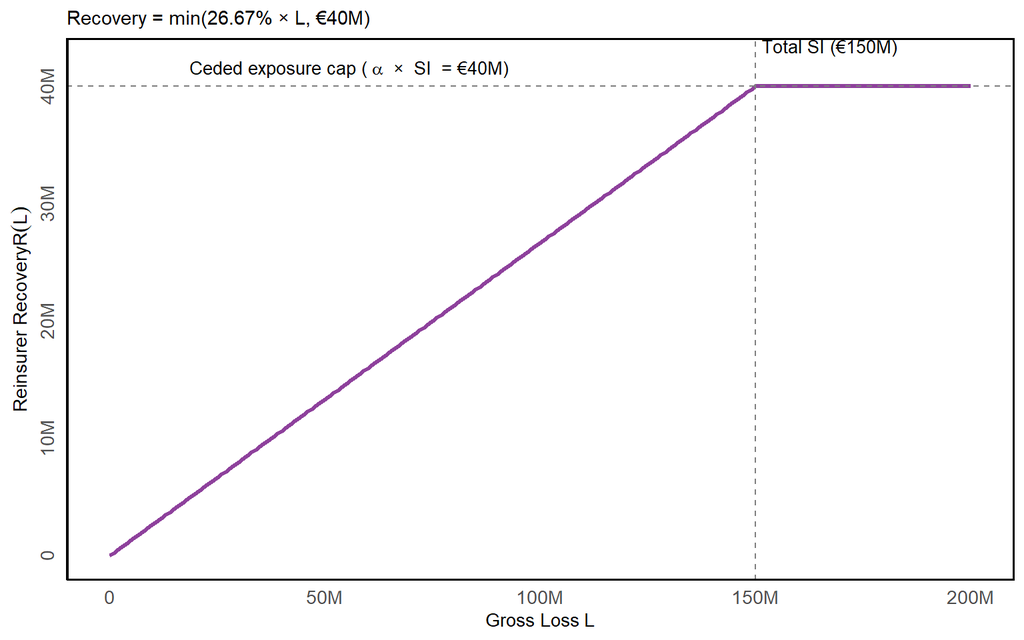

```r
# This is pure proportional participation
# Sum Insured = €150M, Retention = €10M, Lines = 4, Capacity = €40M
# α = min(nA/SI, max(0, 1 - A/SI)) = min(40/150, 0.9333) = 26.67%
# Cap: α × SI = 0.2667 × 150M = €40M

alpha_surplus  = 4 * 10 / 150
SI_surplus     = 150e6
M_capacity     = alpha_surplus * SI_surplus  # €40M (the ceded exposure)
L_demo_surplus = seq(0, 200e6, by = 1e6)
R_surplus_demo = pmin(alpha_surplus * L_demo_surplus, M_capacity)

df_surplus = data.frame(Loss = L_demo_surplus, Recovery = R_surplus_demo)

ggplot(df_surplus, aes(x = Loss, y = Recovery)) +
  geom_line(linewidth = 1.2, color = plotColors$Base$Purple) +
  geom_hline(yintercept = M_capacity, linetype = "dashed", color = "grey50") +
  geom_vline(xintercept = SI_surplus, linetype = "dashed", color = "grey50") +
  scale_x_continuous(labels = label_number(scale_cut = cut_short_scale())) +
  scale_y_continuous(labels = label_number(scale_cut = cut_short_scale()), lim = c(0, 42e6)) +
  labs(
    x        = expression("Gross Loss" ~ L),
    y        = expression("Reinsurer Recovery" ~ R(L)),
    subtitle = "Recovery = min(26.67% × L, €40M)"
  ) +
  annotate("text", x = 0, y = M_capacity, label = expression("Ceded exposure cap (" ~ alpha ~ " × " ~ SI ~ " = €40M)"),
           vjust = -0.5, size = 3.5, hjust = -0.25, parse = TRUE) +
  annotate("text", x = SI_surplus, y = Inf, label = "Total SI (€150M)", hjust = -0.05,
           vjust = 1.05, size = 3.5) +
  theme_minimal() +
  themePlot
```

# 6 Non-Proportional Structures

Contrary to proportional treaties, non‑proportional reinsurance intervenes only for losses exceeding the attachment point $A$ and are designed to protect against tail risk rather than everyday volatility. In this section, we introduce two types of non-proportional structures: an excess of loss contract and a stop-loss contract.

## 6.1 Excess of Loss: “Only Pay When Large Losses Hit”

In an Excess of Loss (XoL) treaty, the reinsurer intervenes only when an insured loss breaches the attachment point $A$ and all losses below this attachment point are fully retained by the insurer. Applied to the Jackie Chan movie, this means the insurer absorbs everyday production losses, while the reinsurer steps in only if a major insured loss threatens the project’s financial viability.

The recovery function for this treaty type is given by

$$R_{\text{XoL}}(X_i) = \min(\max(X_i - A, 0), L)$$

where:

- $A$ = **attachment** (individual claims below this: you pay 100%)
- $L$ = **limit** (reinsurer’s maximum recovery per claim)
- $X_i$ = individual claim

For example, a “€40M excess €10M” (or “40 xs 10” in shorthand) means that

- you self-insure claims below €10M (attachment $A = €10M$),
- claims between €10M–€50M are covered 100% by the reinsurer.
- claims above €50M: reinsurer pays only up to €40M total per claim (their limit $L = €40M$).

> **Reinstatements: Limits Reset After Large Claims.** If a major incident exhausts your reinsurance limit mid‑production, you can reinstate the cover. Hereby you reset the limit to its full amount and are able to continue operating. Reinstatements may be free or may require an additional premium, depending on the treaty terms. This mechanism is critical for high‑risk productions, where losses can occur early and filming must continue. As you are probably aware, Jackie Chan does not stop after a stunt goes wrong. During Rumble in the Bronx, he broke his ankle and continued filming with his foot in a cast. A serious accident happened mid-shoot, but the production kept going. In this case, you want to make sure that if another accident happens next week, you are still insured. Without reinstatements, your coverage would be exhausted after the first incident, leaving you uninsured and forced to halt production. Reinstatements give you fresh coverage limits if another accident occurs.

Figure 6 visualizes the classic XoL layer shape. Recovery is zero below the attachment, then rises one-for-one in the covered layer, and flattens again at the limit. This highlights why XoL targets tail losses without sharing all routine claims.

Figure 6: Excess of Loss recovery function: attachment and limit

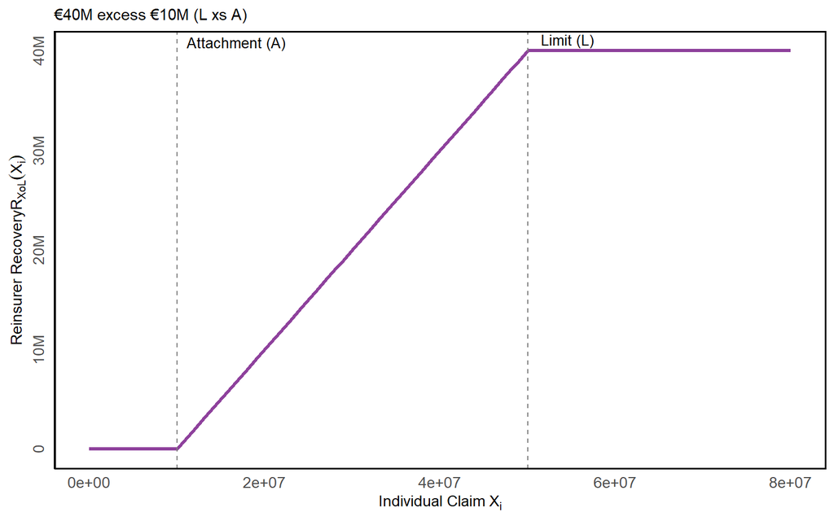

```r
A          = 10e6
L          = 40e6
R_xol_demo = pmin(pmax(X_demo - A, 0), L)

df_xol = data.frame(Claim = X_demo, Recovery = R_xol_demo)

ggplot(df_xol, aes(x = Claim, y = Recovery)) +
  geom_line(linewidth = 1.2, color = plotColors$Base$Purple) +
  geom_vline(xintercept = A, linetype = "dashed", color = "grey50") +
  geom_vline(xintercept = A + L, linetype = "dashed", color = "grey50") +
  scale_y_continuous(labels = label_number(scale_cut = cut_short_scale())) +
  labs(
    x        = expression("Individual Claim" ~ X[i]),
    y        = expression("Reinsurer Recovery" ~ R["XoL"](X[i])),
    subtitle = "€40M excess €10M (L xs A)"
  ) +
  annotate("text", x = A, y = Inf, label = "Attachment (A)", hjust = -0.1, vjust = 1.5, size = 3.5) +
  annotate("text", x = A + L, y = Inf, label = "Limit (L)", hjust = -0.25, vjust = 1.25, size = 3.5) +
  theme_minimal() +
  themePlot
```

Beyond the per-claim attachment and limit, XoL contracts also control total exposure at the portfolio level. Over a full filming season, multiple incidents can accumulate. Several stunt mishaps, a set fire and actor injuries. Reinsurers protect themselves with **aggregate clauses** that cap or defer their total annual liability regardless of how many individual claims occur, the most common being the Annual Aggregate Deductible (AAD) and the Annual Aggregate Limit (AAL).

To explain these, we first define the reinsurer’s aggregate recovery $S_{\text{Re}}$ as the sum of all per-claim reinsurer payouts calculated over the entire contract period

$$S_{\text{Re}} = \sum_{i = 1}^N R_{\text{XoL}}(X_i).$$

For example, if three claims emerged (€15M, €35M, €45M) under a €40M excess €10M XoL, the reinsurer would recover €5M + €25M + €40M = €70M in total (given that we have an unlimited number of reinstatements). This €70M is the $S_{\text{Re}}$ before aggregate clauses reduce it.

> **Annual Aggregate Deductible (AAD):** A deductible applied to the reinsurer’s total aggregate recovery in a year. The reinsurer pays only what exceeds this threshold:
> $$S^{\text{AAD}}_{\text{Re}} = \max(0, S_{\text{Re}} - \text{AAD})$$

> **Annual Aggregate Limit (AAL):** A cap on the reinsurer’s total aggregate liability in a year. The reinsurer pays up to this limit:
> $$S^{\text{AAL}}_{\text{Re}} = \min(\text{AAL}, S_{\text{Re}})$$

> **Combined AAD & AAL:** When both apply together, the reinsurer’s recovery is bounded:
> $$S^{\text{AAD, AAL}}_{\text{Re}} = \min(\text{AAL}, \max(0, S_{\text{Re}} - \text{AAD}))$$

> **Reinstatement equivalence:** Buying an XoL of €L limit with *k* **free reinstatements** is economically equivalent to buying €(k+1)L coverage without reinstatements in a single-contract term. With free reinstatements, the limit resets k times at no cost if it is exhausted.

## 6.2 Stop-Loss Reinsurance

A **Stop‑Loss (SL)** is a non‑proportional reinsurance cover that applies to the **aggregate loss ratio** over a contract period, rather than to individual claims.

Let:

- $S$ denote the aggregate losses over the period,
- $P$ the earned premium,
- $\text{LR} = S / P$ the loss ratio,
- $A_{\text{LR}}$ the stop‑loss **attachment point** (loss‑ratio threshold),
- $L_{\text{LR}}$ the stop‑loss **limit** (maximum loss‑ratio cover).

The reinsurer’s payout is given by
$$R_{\text{SL}}(S)
=
P \cdot \min\!\bigl(\max(\text{LR} - A_{\text{LR}},\, 0),\; L_{\text{LR}}\bigr).$$

Hence, a Stop‑Loss of **40% xs 80%** corresponds to $A_{\text{LR}} = 80\%$ and $L_{\text{LR}} = 40\%$, so that the reinsurer covers the portion of the aggregate loss ratio between 80% and 120%.

### 6.2.1 Example: Jackie Chan Movie with 40% xs 80% Stop-Loss (Loss Ratio Basis)

We illustrate the mechanics of a Stop‑Loss contract using a single high‑risk movie production. The cover is specified on a loss‑ratio basis as **40% xs 80%**.

| Aggregate Loss Ratio ($S/P$) | Interpretation | Reinsurer Pays | You Pay |
| --- | --- | --- | --- |
| 40% | Losses are 40% of premium | 0% of $P$ | 40% of $P$ |
| 80% | Losses are exactly at the attachment | 0% of $P$ | 80% of $P$ |
| 100% | Losses equal premium, so only the slice from 80% to 100% is covered | 20% of $P$ | 80% of $P$ |
| 120% | Losses are 20% above premium, and the full covered layer is hit | 40% of $P$ | 80% of $P$ |
| 160% | Losses are 60% above premium, but the treaty still pays only the covered layer | 40% of $P$ | 120% of $P$ |

> Whether losses arise from one catastrophic accident or ten independent incidents, only the total matters. The reinsurer absorbs the layer between loss ratios 80% and 120%; below 80% nothing is paid, and above 120% the excess comes back to the insurer.

A Stop-Loss treaty is designed to protect against **aggregate production risk**, the cumulative exposure from multiple loss events over the filming period:

- repeated delays and cost overruns;
- cascading incidents;
- operational complexity with many small-to-medium losses.

As such, you are capping total downside, not individual accident size.

# 7 Choosing the Right Structure: EVA and RORAC

The insurer’s next question is economic. Which treaty is actually worth buying? To answer that, we need a criterion that weighs price against protection. EVA and RORAC do this from two different angles.

## 7.1 EVA: Does the Treaty Create Value?

One useful way to compare reinsurance treaties is by calculating **Economic Value Added (EVA)**. The EVA indicates whether the treaty is profitable, once we account for the price of reinsurance and the capital it frees up. The formula is given by

$$\mathrm{EVA}(X) = (\text{SCR}_{\text{gross}} - \text{SCR}_{\text{net}}) \cdot \text{CoC} - \left(\mathbb{E}[\Pi_{\text{gross}}] - \mathbb{E}[\Pi_{\text{net}}]\right)$$

where:

- $\text{SCR}_{\text{gross}}$ is the capital requirement without reinsurance.
- $\text{SCR}_{\text{net}}$ is the capital requirement with reinsurance.
- $\text{CoC}$ is the cost of capital.
- $\mathbb{E}[\Pi_{\text{gross}}]$ is the profit without reinsurance.
- $\mathbb{E}[\Pi_{\text{net}}]$ is the profit with reinsurance.

$\text{SCR}_{\text{gross}} - \text{SCR}_{\text{net}}$ measures how much capital is freed up by buying reinsurance. We multiply this by the CoC to convert the capital relief into an annual economic benefit, expressed in monetary terms. The second part $\mathbb{E}[\Pi_{\text{gross}}] - \mathbb{E}[\Pi_{\text{net}}]$ represents the expected cost of reinsurance. If $\mathrm{EVA} > 0$, the value of the capital relief exceeds the profit ceded to the reinsurer, and the treaty creates economic value for the firm. Conversely, when $\mathrm{EVA} < 0$, buying this specific reinsurance cover is too expensive relative to the amount of risk and capital it removes from the balance sheet.

Let us illustrate this with a simple example where

- $\text{SCR}_{\text{gross}}$ = 100,
- $\text{SCR}_{\text{net}}$ = 70,
- $\text{CoC}$ = 8%,
- $\mathbb{E}[\Pi_{\text{gross}}] - \mathbb{E}[\Pi_{\text{net}}] = 1.5$ because of the treaty.

Then the capital saved is $100 - 70 = 30$, so the capital relief value is $30 \times 8\% = 2.4$. Hence

$$\mathrm{EVA} = 2.4 - 1.5 = 0.9$$

In this simple example, the treaty creates value since $\mathrm{EVA} > 0$.

> **Why Capital Relief Has Value:** If you hold €100M in capital, you could invest it elsewhere (stocks, bonds) and earn ~8% annually. So avoiding the need to hold €30M saves 0.08 × €30M = €2.4M in annual opportunity cost. This is the capital relief value.

## 7.2 RORAC: How Efficiently Is Capital Used?

**RORAC** stands for **Return On Risk-Adjusted Capital**. It tells us how much expected profit we earn per unit of capital required to support the risk.

$$\mathrm{RORAC} = \frac{\mathbb{E}[\Pi_{\text{net}}]}{\text{SCR}_{\text{net}}}.$$

The RORAC measures the **capital efficiency**, reflecting the trade‑off between profit and capital. A treaty may lower expected profit yet improve RORAC if it delivers enough SCR relief. This reflects the fact that RORAC rewards capital efficiency. Earning less profit can be acceptable if it requires significantly less capital. Table 3 gives a simple numerical illustration.

```r
rorac_example = data.frame(
  Item        = c("Expected profit", "SCR", "RORAC"),
  Gross       = c("10", "100", "10%"),
  Net         = c("7", "50", "14%")
)

knitr::kable(rorac_example, align = "lcc", format = "html", caption = "Illustrative RORAC comparison before and after reinsurance", table.attr = "style='width:100%;'")
```

Table 3: Illustrative RORAC comparison before and after reinsurance

| Item | Gross | Net |
| --- | --- | --- |
| Expected profit | 10 | 7 |
| SCR | 100 | 50 |
| RORAC | 10% | 14% |

In this example, the expected profit falls from 10 to 7, but the required capital falls from 100 to 50, so capital efficiency improves. That is why the treaty can have a higher RORAC even when it reduces expected profit.

EVA and RORAC are therefore complementary:

- **EVA** is a euro measure of value creation.
- **RORAC** is a ratio measuring profit per unit of required capital.

With this framework in place, we can now compare different treaty structures on a common basis. EVA tells us which treaty creates the most euro value, while RORAC tells us which treaty uses capital most efficiently.

## 7.3 A Simple Pricing Model

To compare reinsurance structures, we need a concrete pricing framework. Suppose the insurer prices the Jackie Chan movie policy under the **variance principle**

$$P_{\text{gross}} = \mathbb{E}[S] + \theta \cdot \operatorname{Var}(S)$$

where $\theta > 0$ is a loading coefficient. Instead of fixing $\theta$ arbitrarily, we calibrate it so that gross premium carries a 25% loading over expected loss:

$$P_{\text{gross}} = (1 + 0.25)\,\mathbb{E}[S].$$

Combining both expressions gives

$$\theta = \frac{0.25\,\mathbb{E}[S]}{\operatorname{Var}(S)}.$$

This keeps the pricing rule variance-based while forcing an interpretable premium target.

Additionally, to convert premium into underwriting profit, we also need an expense assumption. A simple choice is a fixed **expense ratio**

$$U = \eta \cdot P_{\text{gross}}$$

where $U$ denotes underwriting expenses and $\eta$ is the expense ratio. For illustration, we take $\eta = 12.5\%$, a proxy for acquisition and administration expenses. Similarly, we keep the reinsurance pricing assumption simple

$$C = \mathbb{E}[R] \cdot (1 + \text{load})$$

where $C$ denotes the reinsurance premium and define $\text{load} = 0.35$. Let $S_{\text{net}} = S - R(S)$ denote the insurer’s aggregate loss after reinsurance. Then the insurer’s expected net profit is

$$\mathbb{E}[\Pi_{\text{net}}] = P_{\text{gross}} - U - C - \mathbb{E}[S_{\text{net}}]$$

and without reinsurance

$$\mathbb{E}[\Pi_{\text{gross}}] = P_{\text{gross}} - U - \mathbb{E}[S].$$

Under this setup,

$$\mathbb{E}[\Pi_{\text{gross}}] - \mathbb{E}[\Pi_{\text{net}}] = C - \mathbb{E}[R],$$

since the expense ratio is held constant. So the simplified EVA formula becomes

$$\mathrm{EVA} = (\text{SCR}_{\text{gross}} - \text{SCR}_{\text{net}}) \cdot \text{CoC} - (C - \mathbb{E}[R]).$$

## 7.4 A Concrete Example: €40M Excess of Loss at €10M Attachment

To illustrate the pricing model and metrics, we focus on a specific reinsurance structure: a **€40M Excess of Loss layer at €10M attachment** applied to the Jackie Chan movie. This layer protects against claims between €10M and €50M per incident. Rather than jumping straight to the comparison, we walk through one specific layer to see the mechanics up close.

**Interpreting the Pricing Setup:** Table 4 shows how the gross premium, underwriting expenses, and reinsurance premium combine to produce expected net profit once the €40M xs €10M layer is purchased. In other words, it makes the cost of tail protection explicit. In this example, the table shows that the cost of this tail protection outweighs its benefits, resulting in a negative expected net profit.

```r
A = 10e6    # Attachment point
L = 40e6    # Limit

# Per-claim XoL recovery function R(X_i) = min(max(X_i - A, 0), L)
xol_recovery_per_claim = function(X_i, attachment, limit) {
  pmin(pmax(X_i - attachment, 0), limit)
}

# Apply per-claim recovery to each simulation and aggregate
R_xol = sapply(simulations, function(sim) {
  if (length(sim$claims) == 0) return(0)
  sum(xol_recovery_per_claim(sim$claims, A, L))
})

S_net_xol    = S - R_xol
VaR_99_net   = quantile(S_net_xol, 0.99)
VaR_995_net  = quantile(S_net_xol, 0.995)
TVaR_995_net = mean(S_net_xol[S_net_xol >= VaR_995_net])
K_net        = VaR_995_net - mean(S_net_xol)
K_relief     = K_gross - K_net

cost_of_capital       = 0.08  # 8% annual cost to hold capital
load_assumption       = 0.35  # 35% premium loading
gross_loading_target  = 0.25  # target: gross premium is 25% above E[S]
expense_ratio         = 0.125  # 12.5% underwriting expense ratio
theta                 = gross_loading_target * mean(S) / var(S)  # calibrated variance-principle coefficient
gross_premium         = mean(S) + theta * var(S)
underwriting_expenses = expense_ratio * gross_premium
expected_profit_gross = gross_premium - underwriting_expenses - mean(S)

# Expected recovery
E_R                  = mean(R_xol)
premium_xol          = E_R * (1 + load_assumption)
reinsurance_cost     = premium_xol - E_R
capital_relief_value = cost_of_capital * K_relief
expected_profit_xol  = gross_premium - underwriting_expenses - premium_xol - mean(S_net_xol)
eva_xol              = capital_relief_value - reinsurance_cost
rorac_xol            = expected_profit_xol / K_net
rorac_gross          = expected_profit_gross / K_gross

premium_table = data.frame(
  Component   = c("Gross premium $P_{gross}$", "Underwriting expenses $U$", "Expected gross profit $E[\\Pi_{gross}]$", "Reinsurance premium $C$", "Expected net profit $E[\\Pi_{net}]$"),
  Value       = c(
    paste0("€", format(round(gross_premium/1e6, 2), big.mark=","), "M"),
    paste0("€", format(round(underwriting_expenses/1e6, 2), big.mark=","), "M"),
    paste0("€", format(round(expected_profit_gross/1e6, 2), big.mark=","), "M"),
    paste0("€", format(round(premium_xol/1e6, 2), big.mark=","), "M"),
    paste0("€", format(round(expected_profit_xol/1e6, 2), big.mark=","), "M")
  ),
  Note = c(
    "Variance principle with a calibrated 25% gross loading",
    "$U = 12.5\\% \\times P_{gross}$",
    "$P_{gross} - U - E[S]$",
    "$E[R] \\times (1 + load)$",
    "$P_{gross} - U - C - E[S_{net}]$"
  )
)

knitr::kable(premium_table, align="lrl", format = "html", caption = "Pricing setup for the €40M xs €10M excess-of-loss example", table.attr = "style='width:100%;'")
```

Table 4: Pricing setup for the €40M xs €10M excess-of-loss example

| Component | Value | Note |
| --- | --- | --- |
| Gross premium $P_{gross}$ | €43.94M | Variance principle with a calibrated 25% gross loading |
| Underwriting expenses $U$ | €5.49M | $U = 12.5\% \times P_{gross}$ |
| Expected gross profit $E[\Pi_{gross}]$ | €3.3M | $P_{gross} - U - E[S]$ |
| Reinsurance premium $C$ | €21.15M | $E[R] \times (1 + load)$ |
| Expected net profit $E[\Pi_{net}]$ | €-2.19M | $P_{gross} - U - C - E[S_{net}]$ |

```r
economic_value = data.frame(
  Metric       = c(
    "Capital relief value",
    "Economic cost of reinsurance",
    "EVA",
    "RORAC"
  ),
  Value = c(
    paste0("+€", format(round(capital_relief_value/1e6, 2), big.mark=","), "M"),
    paste0("-€", format(round(reinsurance_cost/1e6, 2), big.mark=","), "M"),
    paste0("€", format(round(eva_xol/1e6, 2), big.mark=","), "M"),
    paste0(format(round(100 * rorac_xol, 2)), "%")
  ),
  Interpretation = c(
    paste0("0.08 × €", format(round(K_relief/1e6, 1), big.mark=","), "M"),
    "Premium minus expected recovery",
    ifelse(eva_xol > 0, "Positive: treaty creates value", "Negative: treaty destroys value"),
    "Expected net profit per euro of remaining capital"
  )
)

knitr::kable(economic_value, align="lrl", format = "html", caption = "EVA and RORAC metrics for the €40M xs €10M excess-of-loss example", table.attr = "style='width:100%;'")
```

Table 5: EVA and RORAC metrics for the €40M xs €10M excess-of-loss example

| Metric | Value | Interpretation |
| --- | --- | --- |
| Capital relief value | +€4.37M | 0.08 × €54.6M |
| Economic cost of reinsurance | -€5.48M | Premium minus expected recovery |
| EVA | €-1.12M | Negative: treaty destroys value |
| RORAC | -3.94% | Expected net profit per euro of remaining capital |

## 7.5 Comparing the Different Reinsurance Structures

Having inspected one reinsurance structure in detail, we proceed to comparing the different structures. Ultimately, we want to know which structure best balances capital relief, profit preservation, and value creation across all candidate options. To answer this, we evaluate all six alternatives: no reinsurance (baseline), 30% Quota Share, Surplus, and three Excess of Loss layers at different attachments.

```r
# Define multiple structures: Quota Share, Surplus, and XoL
test_structures = list(
  list(name = "No reins.", type = "None", c_qs = NA, A = Inf, L = 0, load = 0),
  list(name = "30% Quota Share", type = "QS", c_qs = 0.30, A = NA, L = NA, load = 0.05),
  list(name = "€40M surplus over €10M", type = "Surplus", c_qs = NA, A = 10e6, L = 40e6, load = 0.15),
  list(name = "€20M xs €10M", type = "XoL", c_qs = NA, A = 10e6, L = 20e6, load = 0.35),
  list(name = "€40M xs €10M", type = "XoL", c_qs = NA, A = 10e6, L = 40e6, load = 0.35),
  list(name = "€50M xs €15M", type = "XoL", c_qs = NA, A = 15e6, L = 50e6, load = 0.35)
)

results = data.frame()

for (s in test_structures) {
  if (s$type == "None") {
    R_test     = rep(0, length(S))
    S_net_test = S
  } else if (s$type == "QS") {
    # Quota Share: per-claim recovery R(X_i) = α × X_i, then summed
    R_test = sapply(simulations, function(sim) {
      if (length(sim$claims) == 0) return(0)
      sum(s$c_qs * sim$claims)
    })
    S_net_test = S - R_test
  } else if (s$type == "Surplus") {
    # Surplus: per-claim recovery R(X_i) = min(α_i × X_i, α_i × SI_i), summed
    SI_surplus = 10 * s$A
    n_lines    = s$L / s$A
    c_surplus  = min(n_lines * s$A / SI_surplus, max(0, 1 - s$A / SI_surplus))
    R_test     = sapply(simulations, function(sim) {
      if (length(sim$claims) == 0) return(0)
      # Per-claim recovery: min(α × X_i, α × SI) capped at limit L
      sum(pmin(c_surplus * sim$claims, c_surplus * SI_surplus))
    })
    S_net_test = S - R_test
  } else {
    # XoL: per-claim recovery R(X_i) = min(max(X_i - A, 0), L), summed
    R_test = sapply(simulations, function(sim) {
      if (length(sim$claims) == 0) return(0)
      sum(xol_recovery_per_claim(sim$claims, s$A, s$L))
    })
    S_net_test = S - R_test
  }

  VaR_995_test  = quantile(S_net_test, 0.995)
  TVaR_995_test = mean(S_net_test[S_net_test >= VaR_995_test])  # For informational purposes
  K_test        = VaR_995_test - mean(S_net_test)  # Solvency Capital Requirement
  K_relief_test = K_gross - K_test

  E_R_test             = mean(R_test)
  premium_test         = E_R_test * (1 + s$load)
  expected_profit_test = gross_premium - underwriting_expenses - premium_test - mean(S_net_test)

  # EVA and RORAC
  reinsurance_cost_test = premium_test - E_R_test
  EVA_test              = (cost_of_capital * K_relief_test) - reinsurance_cost_test
  RORAC_test            = if (K_test > 0) expected_profit_test / K_test else NA

  results       = rbind(results, data.frame(
    Structure   = s$name,
    K_net_M     = round(K_test/1e6, 1),
    K_relief_M  = round(K_relief_test/1e6, 1),
    ExpProfit_M = round(expected_profit_test/1e6, 1),
    Premium_M   = round(premium_test/1e6, 1),
    EVA_M       = round(EVA_test/1e6, 1),
    RORAC_pct   = round(100 * RORAC_test, 1)
  ))
}

# Create comprehensive comparison table with metric definitions
comparison_full = data.frame(
  Structure     = results$Structure,
  "Net SCR\n(€M)" = results$K_net_M,
  "SCR Relief\n(€M)" = results$K_relief_M,
  "Expected Net\nProfit (€M)" = results$ExpProfit_M,
  "Annual\nPremium (€M)" = results$Premium_M,
  "Annual EVA\n(€M)" = results$EVA_M,
  "RORAC\n(%)" = results$RORAC_pct,
  check.names = FALSE
)

# Metric explanations
metric_guide = data.frame(
  Metric     = c(
    "Net SCR",
    "SCR Relief",
    "Expected Net Profit",
    "Annual Premium",
    "Annual EVA",
    "RORAC"
  ),
  Definition = c(
    "Economic capital required after reinsurance",
    "Difference between gross SCR and net SCR",
    "Gross premium minus underwriting expenses, expected retained loss, and reinsurance premium",
    "What you pay annually to the reinsurer (E[Recovery] × (1 + load))",
    "Economic Value Added: CoC × ΔK - (Reinsurance premium - Expected recovery)",
    "Expected net profit divided by net SCR"
  ),
  Interpretation = c(
    "Lower is better (less capital tied up)",
    "Higher is better (free up capital for other uses)",
    "Higher is better, all else equal",
    "Lower is better (lower cost)",
    "Positive is good (the treaty creates value); negative means it is too expensive for the capital relief it provides",
    "Higher is better (more expected profit per unit of net SCR)"
  )
)
```

Table 6 displays the comparison. Each row represents a different coverage option (no reinsurance, Quota Share, Surplus, or various Excess of Loss layers), with columns tracking capital requirements, expected profit, premium costs, and the EVA and RORAC metrics. Table 7 provides a glossary defining each metric, its interpretation, and why it matters for decision-making.

```r
knitr::kable(
  comparison_full,
  align  = "lrrrrrr",
  format = "html", caption = "Comparison of reinsurance structures: capital, pricing, EVA, and RORAC", table.attr = "style='width:100%;'"
)
```

Table 6: Comparison of reinsurance structures: capital, pricing, EVA, and RORAC

| Structure | Net SCR (€M) | SCR Relief (€M) | Expected Net Profit (€M) | Annual Premium (€M) | Annual EVA (€M) | RORAC (%) |
| --- | --- | --- | --- | --- | --- | --- |
| No reins. | 110.1 | 0.0 | 3.3 | 0.0 | 0.0 | 3.0 |
| 30% Quota Share | 77.1 | 33.0 | 2.8 | 11.1 | 2.1 | 3.6 |
| €40M surplus over €10M | 66.9 | 43.2 | 1.2 | 16.1 | 1.4 | 1.8 |
| €20M xs €10M | 73.8 | 36.4 | -1.6 | 18.8 | -2.0 | -2.1 |
| €40M xs €10M | 55.5 | 54.6 | -2.2 | 21.2 | -1.1 | -3.9 |
| €50M xs €15M | 63.7 | 46.4 | -0.1 | 13.1 | 0.3 | -0.1 |

```r
knitr::kable(
  metric_guide,
  align  = "lll",
  format = "html", caption = "How to read the structure-comparison metrics", table.attr = "style='width:100%;'"
)
```

Table 7: How to read the structure-comparison metrics

| Metric | Definition | Interpretation |
| --- | --- | --- |
| Net SCR | Economic capital required after reinsurance | Lower is better (less capital tied up) |
| SCR Relief | Difference between gross SCR and net SCR | Higher is better (free up capital for other uses) |
| Expected Net Profit | Gross premium minus underwriting expenses, expected retained loss, and reinsurance premium | Higher is better, all else equal |
| Annual Premium | What you pay annually to the reinsurer (E[Recovery] × (1 + load)) | Lower is better (lower cost) |
| Annual EVA | Economic Value Added: CoC × ΔK - (Reinsurance premium - Expected recovery) | Positive is good (the treaty creates value); negative means it is too expensive for the capital relief it provides |
| RORAC | Expected net profit divided by net SCR | Higher is better (more expected profit per unit of net SCR) |

Several patterns emerge when inspecting the table:

**EVA**: This criterion measures whether the capital freed up is worth the reinsurance cost. In this simulation, the **30% Quota Share** achieves the highest EVA (€2.1M), followed by other moderate structures. In contrast, large XoL layers show negative EVA. The €40M xs €10M layer for example, produces an EVA of €-1.1M. This is because the premium load (35%) is too steep relative to the economic benefit of the tail protection. This illustrates a critical lesson: **maximum capital relief does not equal maximum value creation**. You must pay for the protection, and if that price is too high, the deal destroys value.

**RORAC**: The RORAC measures the capital efficiency, by calculating the profit per unit of required capital. To interpret its value, we require a baseline. Without reinsurance, the RORAC equals 3%. In comparison, the 30% Quota Share yields a RORAC of 3.6%. Hence, for this structure, the freed up capital compensates for the ceded profit, as the RORAC is higher than the baseline. In contrast, we observe that the XoL structures have negative RORAC’s. This occurs when the expected profit is negative (e.g., due to steep premiums). In this case, the RORAC is negative and signals value destruction. This points to a fundamental takeaway. Capital relief and RORAC improvement depend critically on whether the reinsurance cost is reasonable relative to the economic benefit gained.

Hence, for this specific example, the analysis indicates that a 30% Quota Share provides the most favorable outcome. It is important to keep in mind that the **optimal treaty choice** is **case‑specific**. It reflects our specific assumptions about loss distribution, premiums, loadings, and capital standards. Different loss shapes, different market pricing, or different company objectives could reverse the ranking.

# 8 What You Should Remember

At the start of this analysis, the whole team was nervous about insuring Jackie Chan. By the end, Sarah had built a full collective risk model, chosen a reinsurance structure, and quantified exactly how much tail risk they could afford to keep. All because Jackie Chan insisted on jumping off a clock tower himself. As it turned out, Jackie only suffered some minor injuries, well within the body of the loss distribution. The 30% quota share covered its share of every claim. Sarah closed her laptop and went home on time for once.

So while this case was framed as insuring cinematic chaos, the conclusions apply beyond film production. The same logic holds for any business facing low-frequency, high-severity risk. Once the narrative is stripped away, the core principles of reinsurance design become clear:

1. **Reinsurance is not about the average year.** It is designed to survive the catastrophic year.
2. **Capital relief is the main value driver.** Most reinsurance doesn’t change your expected loss, it changes your tail risk and the capital you must hold.
3. **Attachment and limit are everything.** Small changes (€10M vs. €15M attachment) create large differences in capital requirements.
4. **The best treaty is model- and objective-dependent.**  
   In this calibration, 30% Quota Share beats the XoL layers on both EVA and RORAC, but different loss assumptions, pricing, capital rules, or business objectives can reverse that ranking.
5. **EVA and RORAC are complementary metrics.**  
   The EVA measures value creation in euros and the RORAC measures expected profit per unit of required capital.
6. **Economics aren’t the whole story.** Regulation, ratings, earnings stability, and stakeholder psychology matter too.